# a5-data-report

Alan Li

11/23/2020

## Summary Information

Based on the [shootings 2018 dataset](http://www.shootingtracker.com), there are 340 shootings occurred in the year of 2018. Also, 373 lives were lost during those 340 shootings. Moreover, city that was most impacted by shootings is Pompano Beach (Parkland). The state that was most impacted by shootings is California. And the date which is most impacted by shootings is February 14, 2018.

## Summary Table

Gun shooting death number ranking by state

| state | Death |
| --- | --- |
| California | 50 |
| Florida | 48 |
| Pennsylvania | 35 |
| Texas | 29 |
| Illinois | 21 |
| Tennessee | 19 |
| Louisiana | 15 |
| North Carolina | 14 |
| Maryland | 13 |
| Ohio | 13 |
| Alabama | 12 |
| Missouri | 12 |
| Indiana | 10 |
| Michigan | 10 |
| Colorado | 9 |
| Arkansas | 7 |
| Kentucky | 7 |
| Delaware | 5 |
| New Mexico | 5 |
| New York | 5 |
| South Carolina | 5 |
| Arizona | 4 |
| New Jersey | 4 |
| Washington | 4 |
| Georgia | 3 |
| Nevada | 3 |
| District of Columbia | 2 |
| Oklahoma | 2 |
| Virginia | 2 |
| Kansas | 1 |
| Minnesota | 1 |
| Mississippi | 1 |
| Nebraska | 1 |
| Wisconsin | 1 |
| Connecticut | 0 |
| Massachusetts | 0 |
| Utah | 0 |

## Description of a Particular Incident

The most horrible gun shooting recorded would be the one located at Pompano Beach (Parkland) with the most people killed. The incident occured at February 14, 2018 and it happened at 5901 Pine Island Rd, Pompano Beach (Parkland), Florida. In this shooting 17 souls were lost and the total number of people injured is 17. The killing spree is the deadliest high school shooting in United States history, surpassing the Columbine High School massacre that killed 15, including the perpetrators, in Colorado in April 1999.

Link to Additional Information: https://www.history.com/this-day-in-history/parkland-marjory-stoneman-douglas-school-shooting

## Interactive Map

[interactive chart not shown]

Each marker represent a gun shooting event. The radius of the marker represent the total casualties of the shooting. As shown on the map, east coast has significantly more shootings than west coast. The shootings tends to happen at major cities like New York and Chicago.

## Plot of your choice

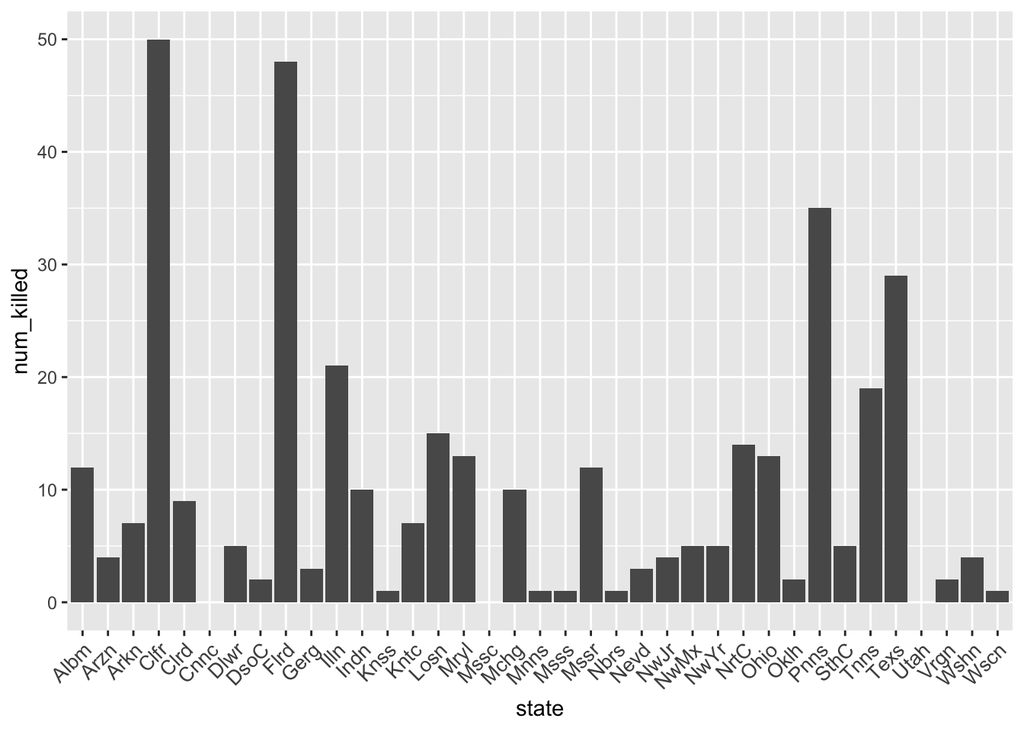

## Question

- Which state(s) has significantly higer deaths compared to others?

## Insights

*California and Florida has nearly 50 deaths during the whole year of 2018. Which is significantly more than other states* Connecticut, Massachusetts and Utah has not even one single death by shooting in the whole year of 2018